# Optimal Treatment Analysis

## Outcome Variable

**Outcome Variable:** haz

## Predictor Variables

**Intervention Variable:** nrooms

**Adjustment Set:**

- arm
- sex
- W_mage
- meducyrs
- feducyrs
- hhwealth_quart
- hfoodsec
- W_mhtcm
- W_mwtkg
- W_mbmi
- W_nchldlt5
- W_parity
- impfloor
- impsan
- safeh20
- delta_W_mage
- delta_meducyrs
- delta_feducyrs
- delta_hhwealth_quart
- delta_hfoodsec
- delta_W_mhtcm
- delta_W_mwtkg
- delta_W_mbmi
- delta_W_nchldlt5
- delta_W_parity
- delta_impfloor
- delta_impsan
- delta_safeh20

## Stratifying Variables

The analysis was stratified on these variable(s):

- agecat
- studyid
- country

## Data Summary

| agecat | studyid | country | nrooms | n_cell | n |
| --- | --- | --- | --- | --- | --- |
| Birth | ki0047075b-MAL-ED | BANGLADESH | 4+ | 12 | 213 |
| Birth | ki0047075b-MAL-ED | BANGLADESH | 1 | 130 | 213 |
| Birth | ki0047075b-MAL-ED | BANGLADESH | 2 | 46 | 213 |
| Birth | ki0047075b-MAL-ED | BANGLADESH | 3 | 25 | 213 |
| Birth | ki0047075b-MAL-ED | BRAZIL | 4+ | 30 | 60 |
| Birth | ki0047075b-MAL-ED | BRAZIL | 1 | 0 | 60 |
| Birth | ki0047075b-MAL-ED | BRAZIL | 2 | 10 | 60 |
| Birth | ki0047075b-MAL-ED | BRAZIL | 3 | 20 | 60 |
| Birth | ki0047075b-MAL-ED | INDIA | 4+ | 2 | 41 |
| Birth | ki0047075b-MAL-ED | INDIA | 1 | 18 | 41 |
| Birth | ki0047075b-MAL-ED | INDIA | 2 | 17 | 41 |
| Birth | ki0047075b-MAL-ED | INDIA | 3 | 4 | 41 |
| Birth | ki0047075b-MAL-ED | NEPAL | 4+ | 15 | 26 |
| Birth | ki0047075b-MAL-ED | NEPAL | 1 | 7 | 26 |
| Birth | ki0047075b-MAL-ED | NEPAL | 2 | 2 | 26 |
| Birth | ki0047075b-MAL-ED | NEPAL | 3 | 2 | 26 |
| Birth | ki0047075b-MAL-ED | PERU | 4+ | 107 | 215 |
| Birth | ki0047075b-MAL-ED | PERU | 1 | 13 | 215 |
| Birth | ki0047075b-MAL-ED | PERU | 2 | 45 | 215 |
| Birth | ki0047075b-MAL-ED | PERU | 3 | 50 | 215 |
| Birth | ki0047075b-MAL-ED | SOUTH AFRICA | 4+ | 67 | 96 |
| Birth | ki0047075b-MAL-ED | SOUTH AFRICA | 1 | 5 | 96 |
| Birth | ki0047075b-MAL-ED | SOUTH AFRICA | 2 | 12 | 96 |
| Birth | ki0047075b-MAL-ED | SOUTH AFRICA | 3 | 12 | 96 |
| Birth | ki0047075b-MAL-ED | TANZANIA, UNITED REPUBLIC OF | 4+ | 49 | 120 |
| Birth | ki0047075b-MAL-ED | TANZANIA, UNITED REPUBLIC OF | 1 | 9 | 120 |
| Birth | ki0047075b-MAL-ED | TANZANIA, UNITED REPUBLIC OF | 2 | 31 | 120 |
| Birth | ki0047075b-MAL-ED | TANZANIA, UNITED REPUBLIC OF | 3 | 31 | 120 |
| Birth | ki1000108-CMC-V-BCS-2002 | INDIA | 4+ | 5 | 92 |
| Birth | ki1000108-CMC-V-BCS-2002 | INDIA | 1 | 38 | 92 |

[output cut: 162 more lines]

The following strata were considered:

- agecat: 24 months, studyid: ki0047075b-MAL-ED, country: BANGLADESH
- agecat: 24 months, studyid: ki0047075b-MAL-ED, country: BRAZIL
- agecat: 24 months, studyid: ki0047075b-MAL-ED, country: INDIA
- agecat: 24 months, studyid: ki0047075b-MAL-ED, country: NEPAL
- agecat: 24 months, studyid: ki0047075b-MAL-ED, country: PERU
- agecat: 24 months, studyid: ki0047075b-MAL-ED, country: SOUTH AFRICA
- agecat: 24 months, studyid: ki0047075b-MAL-ED, country: TANZANIA, UNITED REPUBLIC OF
- agecat: 24 months, studyid: ki1000108-CMC-V-BCS-2002, country: INDIA
- agecat: 24 months, studyid: ki1000108-IRC, country: INDIA
- agecat: 24 months, studyid: ki1017093b-PROVIDE, country: BANGLADESH
- agecat: 24 months, studyid: ki1017093c-NIH-Crypto, country: BANGLADESH
- agecat: 24 months, studyid: ki1113344-GMS-Nepal, country: NEPAL
- agecat: 24 months, studyid: ki1114097-CONTENT, country: PERU
- agecat: 24 months, studyid: ki1135781-COHORTS, country: INDIA
- agecat: 24 months, studyid: kiGH5241-JiVitA-3, country: BANGLADESH
- agecat: 24 months, studyid: kiGH5241-JiVitA-4, country: BANGLADESH
- agecat: 6 months, studyid: ki0047075b-MAL-ED, country: BANGLADESH
- agecat: 6 months, studyid: ki0047075b-MAL-ED, country: BRAZIL
- agecat: 6 months, studyid: ki0047075b-MAL-ED, country: INDIA
- agecat: 6 months, studyid: ki0047075b-MAL-ED, country: NEPAL
- agecat: 6 months, studyid: ki0047075b-MAL-ED, country: PERU
- agecat: 6 months, studyid: ki0047075b-MAL-ED, country: SOUTH AFRICA
- agecat: 6 months, studyid: ki0047075b-MAL-ED, country: TANZANIA, UNITED REPUBLIC OF
- agecat: 6 months, studyid: ki1000108-CMC-V-BCS-2002, country: INDIA
- agecat: 6 months, studyid: ki1000108-IRC, country: INDIA
- agecat: 6 months, studyid: ki1017093b-PROVIDE, country: BANGLADESH
- agecat: 6 months, studyid: ki1017093c-NIH-Crypto, country: BANGLADESH
- agecat: 6 months, studyid: ki1113344-GMS-Nepal, country: NEPAL
- agecat: 6 months, studyid: ki1114097-CONTENT, country: PERU
- agecat: 6 months, studyid: ki1135781-COHORTS, country: INDIA
- agecat: 6 months, studyid: kiGH5241-JiVitA-3, country: BANGLADESH
- agecat: 6 months, studyid: kiGH5241-JiVitA-4, country: BANGLADESH
- agecat: Birth, studyid: ki0047075b-MAL-ED, country: BANGLADESH
- agecat: Birth, studyid: ki0047075b-MAL-ED, country: BRAZIL
- agecat: Birth, studyid: ki0047075b-MAL-ED, country: INDIA
- agecat: Birth, studyid: ki0047075b-MAL-ED, country: NEPAL
- agecat: Birth, studyid: ki0047075b-MAL-ED, country: PERU
- agecat: Birth, studyid: ki0047075b-MAL-ED, country: SOUTH AFRICA
- agecat: Birth, studyid: ki0047075b-MAL-ED, country: TANZANIA, UNITED REPUBLIC OF
- agecat: Birth, studyid: ki1000108-CMC-V-BCS-2002, country: INDIA
- agecat: Birth, studyid: ki1000108-IRC, country: INDIA
- agecat: Birth, studyid: ki1017093b-PROVIDE, country: BANGLADESH
- agecat: Birth, studyid: ki1017093c-NIH-Crypto, country: BANGLADESH
- agecat: Birth, studyid: ki1113344-GMS-Nepal, country: NEPAL
- agecat: Birth, studyid: ki1114097-CONTENT, country: PERU
- agecat: Birth, studyid: ki1135781-COHORTS, country: INDIA
- agecat: Birth, studyid: kiGH5241-JiVitA-3, country: BANGLADESH
- agecat: Birth, studyid: kiGH5241-JiVitA-4, country: BANGLADESH

### Dropped Strata

Some strata were dropped due to rare outcomes:

- agecat: Birth, studyid: ki0047075b-MAL-ED, country: BRAZIL
- agecat: Birth, studyid: ki0047075b-MAL-ED, country: INDIA
- agecat: Birth, studyid: ki0047075b-MAL-ED, country: NEPAL
- agecat: Birth, studyid: ki1114097-CONTENT, country: PERU
- agecat: 6 months, studyid: ki0047075b-MAL-ED, country: BRAZIL
- agecat: 24 months, studyid: ki0047075b-MAL-ED, country: BRAZIL

## Methods Detail

We’re interested in the causal parameters $E[Y_a]$ for all values of $a \in \mathcal{A}$. These parameters represent the mean outcome if, possibly contrary to fact, we intervened to set all units to have $A=a$. Under the randomization and positivity assumptions, these are identified by the statistical parameters $\psi_a=E_W[E_{Y|A,W}(Y|A=a,W)]$. In addition, we’re interested in the mean of $Y$, $E[Y]$ under no intervention (the observed mean). We will estimate these parameters by using SuperLearner to fit the relevant likelihood factors – $E_{Y|A,W}(Y|A=a,W)$ and $p(A=a|W)$, and then updating our likelihood fit using a joint TMLE.

For unadjusted analyses ($W=\{\}$), initial likelihoods were estimated using Lrnr_glm to estimate the simple $E(Y|A)$ and Lrnr_mean to estimate $p(A)$. For adjusted analyses, a small library containing Lrnr_glmnet, Lrnr_xgboost, and Lrnr_mean was used.

Having estimated these parameters, we will then use the delta method to estimate relative risks and attributable risks relative to a prespecified baseline level of $A$.

# Results Detail

## Results Plots

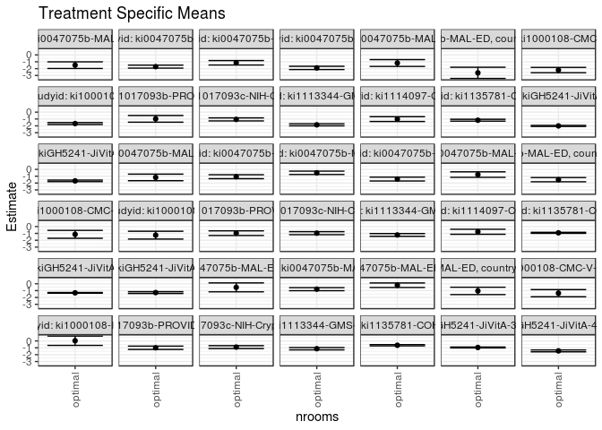

## Results Table

### Parameter: TSM

| agecat | studyid | country | intervention_level | baseline_level | estimate | ci_lower | ci_upper |
| --- | --- | --- | --- | --- | --- | --- | --- |
| Birth | ki0047075b-MAL-ED | BANGLADESH | optimal | observed | -0.5268400 | -1.1774592 | 0.1237793 |
| Birth | ki0047075b-MAL-ED | PERU | optimal | observed | -0.7892218 | -1.0129804 | -0.5654633 |
| Birth | ki0047075b-MAL-ED | SOUTH AFRICA | optimal | observed | -0.2149914 | -0.5448320 | 0.1148491 |
| Birth | ki0047075b-MAL-ED | TANZANIA, UNITED REPUBLIC OF | optimal | observed | -1.0431264 | -1.5768060 | -0.5094467 |
| Birth | ki1000108-CMC-V-BCS-2002 | INDIA | optimal | observed | -1.3739514 | -1.8956397 | -0.8522630 |
| Birth | ki1000108-IRC | INDIA | optimal | observed | 0.0299894 | -0.6485654 | 0.7085441 |
| Birth | ki1017093b-PROVIDE | BANGLADESH | optimal | observed | -0.9945591 | -1.2357872 | -0.7533310 |
| Birth | ki1017093c-NIH-Crypto | BANGLADESH | optimal | observed | -0.8947883 | -1.1038318 | -0.6857448 |
| Birth | ki1113344-GMS-Nepal | NEPAL | optimal | observed | -1.1286988 | -1.2992372 | -0.9581603 |
| Birth | ki1135781-COHORTS | INDIA | optimal | observed | -0.6265978 | -0.7191399 | -0.5340558 |
| Birth | kiGH5241-JiVitA-3 | BANGLADESH | optimal | observed | -0.9511179 | -1.0145101 | -0.8877256 |
| Birth | kiGH5241-JiVitA-4 | BANGLADESH | optimal | observed | -1.4458345 | -1.5821615 | -1.3095074 |
| 6 months | ki0047075b-MAL-ED | BANGLADESH | optimal | observed | -1.1797514 | -1.6588806 | -0.7006223 |
| 6 months | ki0047075b-MAL-ED | INDIA | optimal | observed | -1.0748510 | -1.3628620 | -0.7868400 |
| 6 months | ki0047075b-MAL-ED | NEPAL | optimal | observed | -0.5059949 | -0.7518907 | -0.2600991 |
| 6 months | ki0047075b-MAL-ED | PERU | optimal | observed | -1.4190702 | -1.6990877 | -1.1390527 |
| 6 months | ki0047075b-MAL-ED | SOUTH AFRICA | optimal | observed | -0.7664632 | -1.1699178 | -0.3630085 |
| 6 months | ki0047075b-MAL-ED | TANZANIA, UNITED REPUBLIC OF | optimal | observed | -1.5085801 | -1.8136640 | -1.2034963 |
| 6 months | ki1000108-CMC-V-BCS-2002 | INDIA | optimal | observed | -1.1355065 | -1.7138507 | -0.5571624 |
| 6 months | ki1000108-IRC | INDIA | optimal | observed | -1.2553039 | -1.8251433 | -0.6854645 |
| 6 months | ki1017093b-PROVIDE | BANGLADESH | optimal | observed | -0.9646005 | -1.2983366 | -0.6308644 |
| 6 months | ki1017093c-NIH-Crypto | BANGLADESH | optimal | observed | -0.9644726 | -1.1828351 | -0.7461100 |
| 6 months | ki1113344-GMS-Nepal | NEPAL | optimal | observed | -1.2240268 | -1.4248753 | -1.0231782 |
| 6 months | ki1114097-CONTENT | PERU | optimal | observed | -0.7610132 | -1.1280407 | -0.3939857 |
| 6 months | ki1135781-COHORTS | INDIA | optimal | observed | -0.9174724 | -0.9932149 | -0.8417299 |
| 6 months | kiGH5241-JiVitA-3 | BANGLADESH | optimal | observed | -1.3268217 | -1.3789654 | -1.2746779 |
| 6 months | kiGH5241-JiVitA-4 | BANGLADESH | optimal | observed | -1.2876279 | -1.4185908 | -1.1566651 |
| 24 months | ki0047075b-MAL-ED | BANGLADESH | optimal | observed | -1.4907914 | -1.9740685 | -1.0075144 |
| 24 months | ki0047075b-MAL-ED | INDIA | optimal | observed | -1.7079115 | -1.9263674 | -1.4894556 |
| 24 months | ki0047075b-MAL-ED | NEPAL | optimal | observed | -1.1459430 | -1.4716880 | -0.8201980 |
| 24 months | ki0047075b-MAL-ED | PERU | optimal | observed | -1.8938814 | -2.1299688 | -1.6577940 |
| 24 months | ki0047075b-MAL-ED | SOUTH AFRICA | optimal | observed | -1.1822768 | -1.6823721 | -0.6821816 |
| 24 months | ki0047075b-MAL-ED | TANZANIA, UNITED REPUBLIC OF | optimal | observed | -2.6140656 | -3.4320173 | -1.7961139 |
| 24 months | ki1000108-CMC-V-BCS-2002 | INDIA | optimal | observed | -2.2059412 | -2.5937567 | -1.8181258 |
| 24 months | ki1000108-IRC | INDIA | optimal | observed | -1.6631105 | -1.8067333 | -1.5194877 |
| 24 months | ki1017093b-PROVIDE | BANGLADESH | optimal | observed | -0.9806614 | -1.4684939 | -0.4928288 |
| 24 months | ki1017093c-NIH-Crypto | BANGLADESH | optimal | observed | -1.0607922 | -1.2824313 | -0.8391531 |
| 24 months | ki1113344-GMS-Nepal | NEPAL | optimal | observed | -1.8486382 | -1.9997981 | -1.6974783 |
| 24 months | ki1114097-CONTENT | PERU | optimal | observed | -1.0136621 | -1.3616148 | -0.6657093 |
| 24 months | ki1135781-COHORTS | INDIA | optimal | observed | -1.1778344 | -1.3155394 | -1.0401294 |
| 24 months | kiGH5241-JiVitA-3 | BANGLADESH | optimal | observed | -2.0091117 | -2.0846643 | -1.9335590 |
| 24 months | kiGH5241-JiVitA-4 | BANGLADESH | optimal | observed | -1.6823035 | -1.7942135 | -1.5703935 |

### Parameter: E(Y)

| agecat | studyid | country | intervention_level | baseline_level | estimate | ci_lower | ci_upper |
| --- | --- | --- | --- | --- | --- | --- | --- |
| Birth | ki0047075b-MAL-ED | BANGLADESH | observed | observed | -1.0530516 | -1.1896058 | -0.9164975 |
| Birth | ki0047075b-MAL-ED | PERU | observed | observed | -0.9141395 | -1.0364098 | -0.7918693 |
| Birth | ki0047075b-MAL-ED | SOUTH AFRICA | observed | observed | -0.5523958 | -0.7550074 | -0.3497843 |
| Birth | ki0047075b-MAL-ED | TANZANIA, UNITED REPUBLIC OF | observed | observed | -1.1225000 | -1.3335666 | -0.9114334 |
| Birth | ki1000108-CMC-V-BCS-2002 | INDIA | observed | observed | -0.9611957 | -1.1776967 | -0.7446946 |
| Birth | ki1000108-IRC | INDIA | observed | observed | -0.3079016 | -0.4694769 | -0.1463262 |
| Birth | ki1017093b-PROVIDE | BANGLADESH | observed | observed | -0.8851020 | -0.9601332 | -0.8100709 |
| Birth | ki1017093c-NIH-Crypto | BANGLADESH | observed | observed | -0.9094945 | -0.9809370 | -0.8380521 |
| Birth | ki1113344-GMS-Nepal | NEPAL | observed | observed | -1.0851580 | -1.1651811 | -1.0051350 |
| Birth | ki1135781-COHORTS | INDIA | observed | observed | -0.6777626 | -0.7107167 | -0.6448086 |
| Birth | kiGH5241-JiVitA-3 | BANGLADESH | observed | observed | -1.1730044 | -1.2010793 | -1.1449294 |
| Birth | kiGH5241-JiVitA-4 | BANGLADESH | observed | observed | -1.5236135 | -1.5727559 | -1.4744711 |
| 6 months | ki0047075b-MAL-ED | BANGLADESH | observed | observed | -1.2031806 | -1.3209873 | -1.0853738 |
| 6 months | ki0047075b-MAL-ED | INDIA | observed | observed | -1.2069078 | -1.3255669 | -1.0882487 |
| 6 months | ki0047075b-MAL-ED | NEPAL | observed | observed | -0.5610593 | -0.6737915 | -0.4483272 |
| 6 months | ki0047075b-MAL-ED | PERU | observed | observed | -1.3293333 | -1.4383829 | -1.2202838 |
| 6 months | ki0047075b-MAL-ED | SOUTH AFRICA | observed | observed | -1.0554016 | -1.1850591 | -0.9257441 |
| 6 months | ki0047075b-MAL-ED | TANZANIA, UNITED REPUBLIC OF | observed | observed | -1.3687449 | -1.4907629 | -1.2467270 |
| 6 months | ki1000108-CMC-V-BCS-2002 | INDIA | observed | observed | -1.4234508 | -1.5645974 | -1.2823042 |
| 6 months | ki1000108-IRC | INDIA | observed | observed | -1.2470123 | -1.3779341 | -1.1160906 |
| 6 months | ki1017093b-PROVIDE | BANGLADESH | observed | observed | -1.0916915 | -1.1661176 | -1.0172654 |
| 6 months | ki1017093c-NIH-Crypto | BANGLADESH | observed | observed | -1.1986783 | -1.2700937 | -1.1272630 |
| 6 months | ki1113344-GMS-Nepal | NEPAL | observed | observed | -1.3508392 | -1.4290633 | -1.2726152 |
| 6 months | ki1114097-CONTENT | PERU | observed | observed | -0.3139217 | -0.4868486 | -0.1409948 |
| 6 months | ki1135781-COHORTS | INDIA | observed | observed | -1.0413281 | -1.0740395 | -1.0086167 |
| 6 months | kiGH5241-JiVitA-3 | BANGLADESH | observed | observed | -1.3357956 | -1.3588816 | -1.3127096 |
| 6 months | kiGH5241-JiVitA-4 | BANGLADESH | observed | observed | -1.3440477 | -1.3813060 | -1.3067894 |
| 24 months | ki0047075b-MAL-ED | BANGLADESH | observed | observed | -1.9789151 | -2.1055330 | -1.8522972 |
| 24 months | ki0047075b-MAL-ED | INDIA | observed | observed | -1.8848458 | -2.0096941 | -1.7599975 |
| 24 months | ki0047075b-MAL-ED | NEPAL | observed | observed | -1.3118640 | -1.4315132 | -1.1922149 |
| 24 months | ki0047075b-MAL-ED | PERU | observed | observed | -1.7544776 | -1.8753255 | -1.6336298 |
| 24 months | ki0047075b-MAL-ED | SOUTH AFRICA | observed | observed | -1.6491807 | -1.7842885 | -1.5140729 |
| 24 months | ki0047075b-MAL-ED | TANZANIA, UNITED REPUBLIC OF | observed | observed | -2.6451636 | -2.7802323 | -2.5100948 |
| 24 months | ki1000108-CMC-V-BCS-2002 | INDIA | observed | observed | -2.5588679 | -2.6583730 | -2.4593629 |
| 24 months | ki1000108-IRC | INDIA | observed | observed | -1.8014906 | -1.8952579 | -1.7077232 |
| 24 months | ki1017093b-PROVIDE | BANGLADESH | observed | observed | -1.6024221 | -1.6857420 | -1.5191023 |
| 24 months | ki1017093c-NIH-Crypto | BANGLADESH | observed | observed | -1.4412646 | -1.5249156 | -1.3576135 |
| 24 months | ki1113344-GMS-Nepal | NEPAL | observed | observed | -1.8874180 | -1.9728588 | -1.8019773 |
| 24 months | ki1114097-CONTENT | PERU | observed | observed | -0.6962195 | -0.8674103 | -0.5250287 |
| 24 months | ki1135781-COHORTS | INDIA | observed | observed | -2.2131714 | -2.2523749 | -2.1739679 |
| 24 months | kiGH5241-JiVitA-3 | BANGLADESH | observed | observed | -2.0196832 | -2.0473250 | -1.9920413 |
| 24 months | kiGH5241-JiVitA-4 | BANGLADESH | observed | observed | -1.7803708 | -1.8158650 | -1.7448765 |

### Parameter: PAR

| agecat | studyid | country | intervention_level | baseline_level | estimate | ci_lower | ci_upper |
| --- | --- | --- | --- | --- | --- | --- | --- |
| Birth | ki0047075b-MAL-ED | BANGLADESH | optimal | observed | -0.5262117 | -1.1582071 | 0.1057837 |
| Birth | ki0047075b-MAL-ED | PERU | optimal | observed | -0.1249177 | -0.3363813 | 0.0865459 |
| Birth | ki0047075b-MAL-ED | SOUTH AFRICA | optimal | observed | -0.3374044 | -0.7126992 | 0.0378904 |
| Birth | ki0047075b-MAL-ED | TANZANIA, UNITED REPUBLIC OF | optimal | observed | -0.0793736 | -0.6188796 | 0.4601323 |
| Birth | ki1000108-CMC-V-BCS-2002 | INDIA | optimal | observed | 0.4127557 | -0.0835238 | 0.9090353 |
| Birth | ki1000108-IRC | INDIA | optimal | observed | -0.3378909 | -0.9978587 | 0.3220769 |
| Birth | ki1017093b-PROVIDE | BANGLADESH | optimal | observed | 0.1094571 | -0.1253647 | 0.3442788 |
| Birth | ki1017093c-NIH-Crypto | BANGLADESH | optimal | observed | -0.0147062 | -0.2100931 | 0.1806807 |
| Birth | ki1113344-GMS-Nepal | NEPAL | optimal | observed | 0.0435407 | -0.1115816 | 0.1986630 |
| Birth | ki1135781-COHORTS | INDIA | optimal | observed | -0.0511648 | -0.1373723 | 0.0350427 |
| Birth | kiGH5241-JiVitA-3 | BANGLADESH | optimal | observed | -0.2218865 | -0.2836856 | -0.1600874 |
| Birth | kiGH5241-JiVitA-4 | BANGLADESH | optimal | observed | -0.0777790 | -0.2127285 | 0.0571705 |
| 6 months | ki0047075b-MAL-ED | BANGLADESH | optimal | observed | -0.0234291 | -0.4914742 | 0.4446160 |
| 6 months | ki0047075b-MAL-ED | INDIA | optimal | observed | -0.1320568 | -0.4090739 | 0.1449602 |
| 6 months | ki0047075b-MAL-ED | NEPAL | optimal | observed | -0.0550644 | -0.2815171 | 0.1713883 |
| 6 months | ki0047075b-MAL-ED | PERU | optimal | observed | 0.0897369 | -0.1564374 | 0.3359113 |
| 6 months | ki0047075b-MAL-ED | SOUTH AFRICA | optimal | observed | -0.2889384 | -0.6779232 | 0.1000463 |
| 6 months | ki0047075b-MAL-ED | TANZANIA, UNITED REPUBLIC OF | optimal | observed | 0.1398352 | -0.1416470 | 0.4213174 |
| 6 months | ki1000108-CMC-V-BCS-2002 | INDIA | optimal | observed | -0.2879442 | -0.8526408 | 0.2767524 |
| 6 months | ki1000108-IRC | INDIA | optimal | observed | 0.0082916 | -0.5371373 | 0.5537204 |
| 6 months | ki1017093b-PROVIDE | BANGLADESH | optimal | observed | -0.1270910 | -0.4573620 | 0.2031800 |
| 6 months | ki1017093c-NIH-Crypto | BANGLADESH | optimal | observed | -0.2342058 | -0.4402113 | -0.0282002 |
| 6 months | ki1113344-GMS-Nepal | NEPAL | optimal | observed | -0.1268125 | -0.3070427 | 0.0534178 |
| 6 months | ki1114097-CONTENT | PERU | optimal | observed | 0.4470915 | 0.1033105 | 0.7908724 |
| 6 months | ki1135781-COHORTS | INDIA | optimal | observed | -0.1238557 | -0.2000901 | -0.0476212 |
| 6 months | kiGH5241-JiVitA-3 | BANGLADESH | optimal | observed | -0.0089740 | -0.0576827 | 0.0397348 |
| 6 months | kiGH5241-JiVitA-4 | BANGLADESH | optimal | observed | -0.0564197 | -0.1801582 | 0.0673187 |
| 24 months | ki0047075b-MAL-ED | BANGLADESH | optimal | observed | -0.4881237 | -0.9654542 | -0.0107932 |
| 24 months | ki0047075b-MAL-ED | INDIA | optimal | observed | -0.1769343 | -0.3510896 | -0.0027790 |
| 24 months | ki0047075b-MAL-ED | NEPAL | optimal | observed | -0.1659210 | -0.4666787 | 0.1348366 |
| 24 months | ki0047075b-MAL-ED | PERU | optimal | observed | 0.1394038 | -0.0765338 | 0.3553413 |
| 24 months | ki0047075b-MAL-ED | SOUTH AFRICA | optimal | observed | -0.4669038 | -0.9496227 | 0.0158150 |
| 24 months | ki0047075b-MAL-ED | TANZANIA, UNITED REPUBLIC OF | optimal | observed | -0.0310979 | -0.8169178 | 0.7547219 |
| 24 months | ki1000108-CMC-V-BCS-2002 | INDIA | optimal | observed | -0.3529267 | -0.7396563 | 0.0338028 |
| 24 months | ki1000108-IRC | INDIA | optimal | observed | -0.1383801 | -0.2496551 | -0.0271050 |
| 24 months | ki1017093b-PROVIDE | BANGLADESH | optimal | observed | -0.6217608 | -1.0988679 | -0.1446536 |
| 24 months | ki1017093c-NIH-Crypto | BANGLADESH | optimal | observed | -0.3804724 | -0.5903248 | -0.1706200 |
| 24 months | ki1113344-GMS-Nepal | NEPAL | optimal | observed | -0.0387798 | -0.1652841 | 0.0877245 |
| 24 months | ki1114097-CONTENT | PERU | optimal | observed | 0.3174426 | 0.0167359 | 0.6181493 |
| 24 months | ki1135781-COHORTS | INDIA | optimal | observed | -1.0353370 | -1.1741723 | -0.8965017 |
| 24 months | kiGH5241-JiVitA-3 | BANGLADESH | optimal | observed | -0.0105715 | -0.0808227 | 0.0596798 |
| 24 months | kiGH5241-JiVitA-4 | BANGLADESH | optimal | observed | -0.0980673 | -0.2038384 | 0.0077039 |